# MA321 Quiz 3 Review: Time Series

Name: ______________________________

Calculator allowed. No notes, no phone, no internet. Show your work.

**1.** Here are the actual demand and the forecast for 3 months. Find the MAPE.

| Month | Actual | Forecast |  |  |  |
| --- | --- | --- | --- | --- | --- |
| 1 | 50 | 45 |  |  |  |
| 2 | 80 | 88 |  |  |  |
| 3 | 40 | 50 |  |  |  |

MAPE = ______________

**2.** Answer True or False for each.

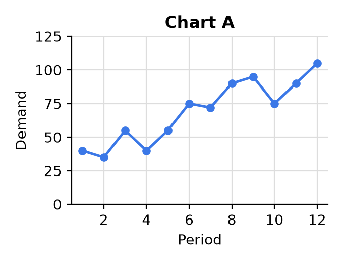

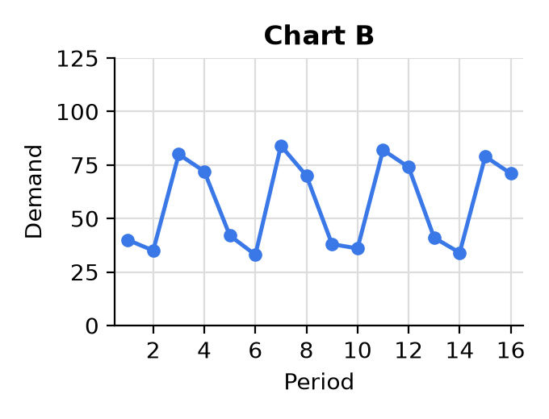

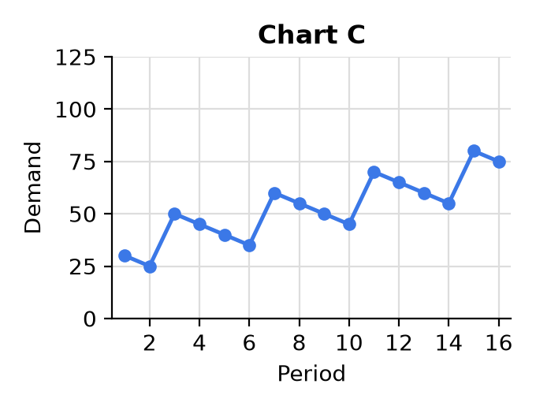

1. True / False: Chart B is stationary.
2. True / False: Chart A has seasonality based on quarters.
3. True / False: Chart C has a trend.
4. True / False: Chart A has more noise than Chart C.
5. True / False: Chart C is stationary.

**3.** Suppose you have an average baseline of 20 units per month. The seasonal indices for the next 6 months are 0.6, 1.2, 0.95, 1.1, 1.4, 0.75.

1. Forecast the next 6 months.
2. Forecast the next 6 months if your average baseline were 20% lower.

**4.**

1. Forecast 1 has a MAPE of 30% and forecast 2 has a MAPE of 12%. Which one is more accurate?
2. Describe in words how the graph of the forecast compares to the graph of the actuals when the MAPE is 3%.
3. True or False: MAPE can be over 100%.

**5.** Here are the actual sales and the seasonal indices for 6 months.

| Month | Actual | Index | Deseasonalized |
| --- | --- | --- | --- |
| January | 36 | 0.8 |  |
| February | 54 | 0.9 |  |
| March | 50 | 1.0 |  |
| April | 60 | 1.2 |  |
| May | 63 | 1.5 |  |
| June | 30 | 0.6 |  |

1. Find the deseasonalized demand for each month and fill it in.
2. Compared to expectations, which month was the best overall and which was the worst? Explain.